# E_COMPANY

STEP 1: Import all the required libriaries

```python
import numpy as np
import matplotlib.pyplot as plt
import pandas as pd
```

STEP 2: Upload the required dataset

```python
df2 = pd.read_csv("online_shoppers.csv")
```

STEP 3: Get the size of the dataset

```python
df2.shape
```

```
(12330, 18)
```

STEP 4: Get first 10 records from the dataset

```python
df2.head(10)
```

|  | Administrative | Administrative_Duration | Informational | Informational_Duration | ProductRelated | Product Related_Duration | BounceRates | Exit Rates | PageValues | SpecialDay | Month | OperatingSystems | Browser | Region | TrafficType | VisitorType | Weekend | Revenue |
| --- | --- | --- | --- | --- | --- | --- | --- | --- | --- | --- | --- | --- | --- | --- | --- | --- | --- | --- |
| 0 | 0 | 0.0 | 0 | 0.0 | 1 | 0.000000 | 0.200000 | 0.200000 | 0.0 | 0.0 | Feb | 1 | 1 | 1 | 1 | Returning_Visitor | False | False |
| 1 | 0 | 0.0 | 0 | 0.0 | 2 | 64.000000 | 0.000000 | 0.100000 | 0.0 | 0.0 | Feb | 2 | 2 | 1 | 2 | Returning_Visitor | False | False |
| 2 | 0 | 0.0 | 0 | 0.0 | 1 | 0.000000 | 0.200000 | 0.200000 | 0.0 | 0.0 | Feb | 4 | 1 | 9 | 3 | Returning_Visitor | False | False |
| 3 | 0 | 0.0 | 0 | 0.0 | 2 | 2.666667 | 0.050000 | 0.140000 | 0.0 | 0.0 | Feb | 3 | 2 | 2 | 4 | Returning_Visitor | False | False |
| 4 | 0 | 0.0 | 0 | 0.0 | 10 | 627.500000 | 0.020000 | 0.050000 | 0.0 | 0.0 | Feb | 3 | 3 | 1 | 4 | Returning_Visitor | True | False |
| 5 | 0 | 0.0 | 0 | 0.0 | 19 | 154.216667 | 0.015789 | 0.024561 | 0.0 | 0.0 | Feb | 2 | 2 | 1 | 3 | Returning_Visitor | False | False |
| 6 | 0 | 0.0 | 0 | 0.0 | 1 | 0.000000 | 0.200000 | 0.200000 | 0.0 | 0.4 | Feb | 2 | 4 | 3 | 3 | Returning_Visitor | False | False |
| 7 | 1 | 0.0 | 0 | 0.0 | 0 | 0.000000 | 0.200000 | 0.200000 | 0.0 | 0.0 | Feb | 1 | 2 | 1 | 5 | Returning_Visitor | True | False |
| 8 | 0 | 0.0 | 0 | 0.0 | 2 | 37.000000 | 0.000000 | 0.100000 | 0.0 | 0.8 | Feb | 2 | 2 | 2 | 3 | Returning_Visitor | False | False |
| 9 | 0 | 0.0 | 0 | 0.0 | 3 | 738.000000 | 0.000000 | 0.022222 | 0.0 | 0.4 | Feb | 2 | 4 | 1 | 2 | Returning_Visitor | False | False |

```python
df2.info()
```

```
<class 'pandas.core.frame.DataFrame'>
RangeIndex: 12330 entries, 0 to 12329
Data columns (total 18 columns):
 #   Column                    Non-Null Count  Dtype
---  ------                    --------------  -----
 0   Administrative            12330 non-null  int64
 1   Administrative_Duration   12330 non-null  float64
 2   Informational             12330 non-null  int64
 3   Informational_Duration    12330 non-null  float64
 4   ProductRelated            12330 non-null  int64
 5   Product Related_Duration  12330 non-null  float64
 6   BounceRates               12330 non-null  float64
 7   Exit Rates                12330 non-null  float64
 8   PageValues                12330 non-null  float64
 9   SpecialDay                12330 non-null  float64
 10  Month                     12330 non-null  object
 11  OperatingSystems          12330 non-null  int64
 12  Browser                   12330 non-null  int64
 13  Region                    12330 non-null  int64
 14  TrafficType               12330 non-null  int64
 15  VisitorType               12330 non-null  object
 16  Weekend                   12330 non-null  bool
 17  Revenue                   12330 non-null  bool
dtypes: bool(2), float64(7), int64(7), object(2)
memory usage: 1.5+ MB
```

STEP 5: Get the descriptive statistics of the dataset

```python
df2.describe()
```

|  | Administrative | Administrative_Duration | Informational | Informational_Duration | ProductRelated | Product Related_Duration | BounceRates | Exit Rates | PageValues | SpecialDay | OperatingSystems | Browser | Region | TrafficType |
| --- | --- | --- | --- | --- | --- | --- | --- | --- | --- | --- | --- | --- | --- | --- |
| count | 12330.000000 | 12330.000000 | 12330.000000 | 12330.000000 | 12330.000000 | 12330.000000 | 12330.000000 | 12330.000000 | 12330.000000 | 12330.000000 | 12330.000000 | 12330.000000 | 12330.000000 | 12330.000000 |
| mean | 2.315166 | 80.818611 | 0.503569 | 34.472398 | 31.731468 | 1194.746220 | 0.022191 | 0.043073 | 5.889258 | 0.061427 | 2.124006 | 2.357097 | 3.147364 | 4.069586 |
| std | 3.321784 | 176.779107 | 1.270156 | 140.749294 | 44.475503 | 1913.669288 | 0.048488 | 0.048597 | 18.568437 | 0.198917 | 0.911325 | 1.717277 | 2.401591 | 4.025169 |
| min | 0.000000 | 0.000000 | 0.000000 | 0.000000 | 0.000000 | 0.000000 | 0.000000 | 0.000000 | 0.000000 | 0.000000 | 1.000000 | 1.000000 | 1.000000 | 1.000000 |
| 25% | 0.000000 | 0.000000 | 0.000000 | 0.000000 | 7.000000 | 184.137500 | 0.000000 | 0.014286 | 0.000000 | 0.000000 | 2.000000 | 2.000000 | 1.000000 | 2.000000 |
| 50% | 1.000000 | 7.500000 | 0.000000 | 0.000000 | 18.000000 | 598.936905 | 0.003112 | 0.025156 | 0.000000 | 0.000000 | 2.000000 | 2.000000 | 3.000000 | 2.000000 |
| 75% | 4.000000 | 93.256250 | 0.000000 | 0.000000 | 38.000000 | 1464.157214 | 0.016813 | 0.050000 | 0.000000 | 0.000000 | 3.000000 | 2.000000 | 4.000000 | 4.000000 |
| max | 27.000000 | 3398.750000 | 24.000000 | 2549.375000 | 705.000000 | 63973.522230 | 0.200000 | 0.200000 | 361.763742 | 1.000000 | 8.000000 | 13.000000 | 9.000000 | 20.000000 |

STEP 6: Count of missing values

```python
mv=df2.isnull().sum()
mv
```

```
Administrative              0
Administrative_Duration     0
Informational               0
Informational_Duration      0
ProductRelated              0
Product Related_Duration    0
BounceRates                 0
Exit Rates                  0
PageValues                  0
SpecialDay                  0
Month                       0
OperatingSystems            0
Browser                     0
Region                      0
TrafficType                 0
VisitorType                 0
Weekend                     0
Revenue                     0
dtype: int64
```

STEP 7: Plotting the Percentage of Customers have brought Revenue."True" means customers has brought the product and "False" means customer did not buy the product"

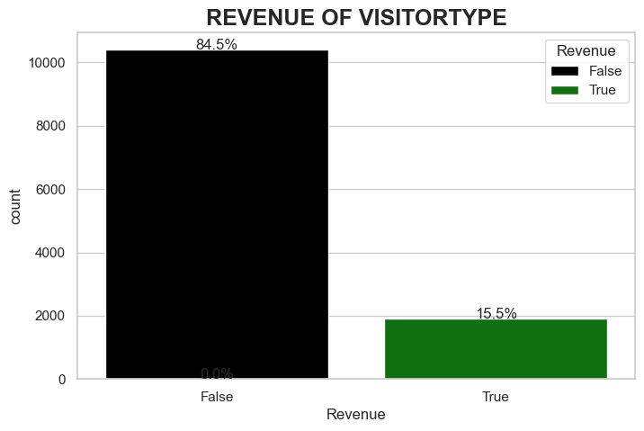

```python
import seaborn as sns
sns.set(style="whitegrid")
plt.figure(figsize=(8,5))
total = (len(df2))

ax = sns.countplot(x= "Revenue", hue='Revenue', data=df2, palette=("black", "green", 'red'))

for p in ax.patches:
    percentage = '{:.1f}%'.format(100 * p.get_height()/total)
    x = p.get_x() + p.get_width()/2
    y = p.get_height()
    ax.annotate(percentage, (x,y), ha='center')
    plt.title('REVENUE OF VISITORTYPE', fontweight='bold', size='18')
    #plt.show()
```

STEP 8: Distribution of VisitorType

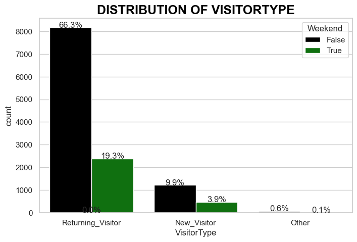

```python
df2['VisitorType'].value_counts()
sns.set(style="whitegrid")
plt.figure(figsize=(8,5))
total = (len(df2))

ax = sns.countplot(x= "VisitorType", hue='Weekend', data=df2, palette=("black", "green", "red"))

for p in ax.patches:
    percentage = '{:.1f}%'.format(100 * p.get_height()/total)
    x = p.get_x() + p.get_width()/2
    y = p.get_height()
    ax.annotate(percentage, (x,y), ha='center')
    plt.title('DISTRIBUTION OF VISITORTYPE', fontweight='bold', size= 18, color='black')
    #plt.show()
```

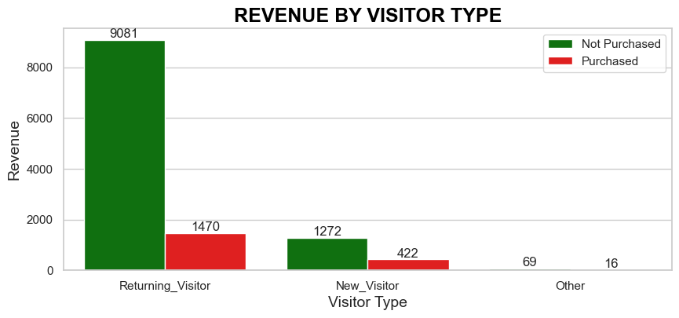

```python
plt.figure(figsize=(10,4))
plt.title("REVENUE BY VISITOR TYPE", fontsize=18, fontweight='bold', color='black')
ax = sns.countplot(x= "VisitorType", data=df2, hue='Revenue', palette=('green','Red', 'black'))
ax.legend(labels=['Not Purchased', 'Purchased'])
for i in ax.containers:
    ax.bar_label(i)
    plt.xlabel("Visitor Type",  fontsize=14)
    plt.ylabel("Revenue", fontsize=14)
#plt.xticks(fontsize=10)
#plt.yticks(fontsize=10)
    #plt.show()
```

STEP 11: Distribution of Customers based on Different Traffic Type Codes

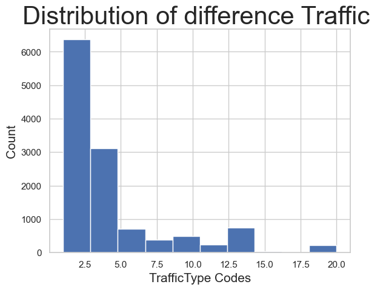

```python
plt.hist(df2['TrafficType'])
plt.title('Distribution of difference Traffic ',fontsize = 30)
plt.xlabel('TrafficType Codes', fontsize = 15)
plt.ylabel('Count', fontsize = 15)
```

STEP 12: Distribution of Customer Based on Region Codes

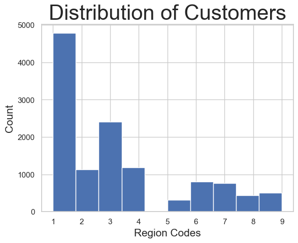

```python
plt.hist(df2['Region'])
plt.title('Distribution of Customers', fontsize = 30)
plt.xlabel('Region Codes', fontsize = 15)
plt.ylabel('Count', fontsize = 15)
```

STEP 13: Distribution of Customers over OperatingSystems

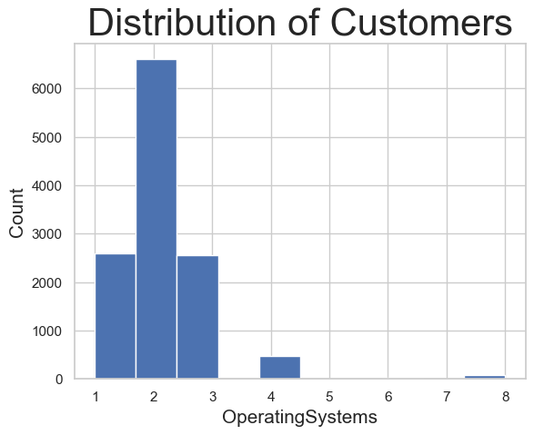

```python
plt.hist(df2['OperatingSystems'])
plt.title('Distribution of Customers', fontsize = 30)
plt.xlabel('OperatingSystems', fontsize = 15)
plt.ylabel('Count', fontsize = 15)
```

Step 14:Distribution of Customers over Months

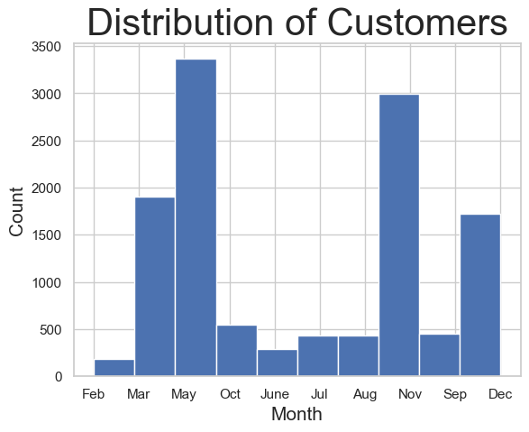

```python
plt.hist(df2['Month'])
plt.title('Distribution of Customers', fontsize = 30)
plt.xlabel('Month', fontsize = 15)
plt.ylabel('Count', fontsize = 15)
```

STEP 15: Distribution of Pagevalues over Revenue. seaborn.stripplot draws a scatterplot where one variable is categorical

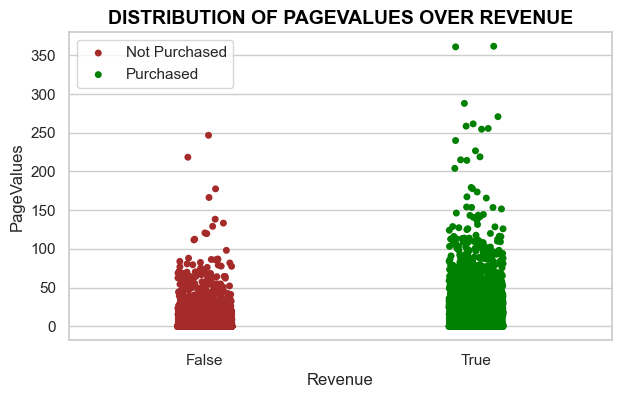

```python
plt.figure(figsize=(7,4))
plt.title("DISTRIBUTION OF PAGEVALUES OVER REVENUE", fontsize=14, fontweight='bold', color='black')
ax = sns.stripplot(x= df2["Revenue"], y= df2["PageValues"], hue= df2['Revenue'], palette=( 'brown', 'green'))
ax.legend(labels=['Not Purchased', 'Purchased'])
for i in ax.containers:
    ax.bar_label(i)
    plt.xlabel("Revenue",  fontsize=14)
    plt.ylabel("PageValues", fontsize=14)
    #plt.show()
```

Step 16: Distribution of Revenue over BounceRates

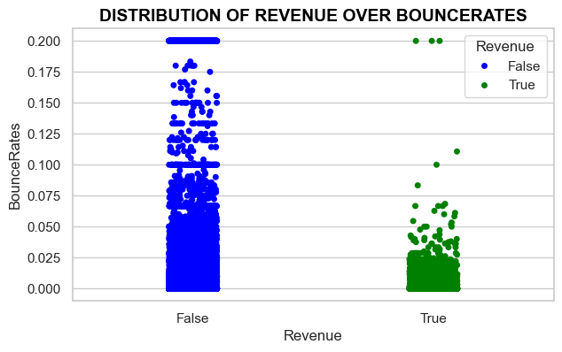

```python
plt.figure(figsize=(7,4))
plt.title("DISTRIBUTION OF REVENUE OVER BOUNCERATES", fontsize=14, fontweight='bold', color='black')
ax = sns.stripplot(x= df2["Revenue"], y= df2["BounceRates"], hue= df2['Revenue'], palette=( 'blue', 'green'))
#ax.legend(labels=['Not Purchased', 'Purchased'])
for i in ax.containers:
    ax.bar_label(i)
    plt.xlabel("Revenue",  fontsize=14)
    plt.ylabel("BounceRates", fontsize=14)
    #plt.show()
```

Step 17: Distribution of TrafficType over Revenue

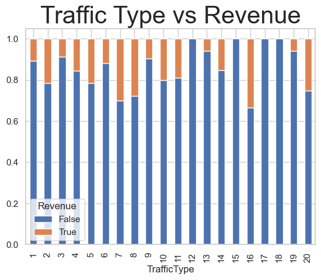

```python
df = pd.crosstab(df2['TrafficType'], df2['Revenue'])
df.div(df.sum(1).astype(float), axis = 0).plot(kind = 'bar', stacked = True)
plt.title('Traffic Type vs Revenue', fontsize = 30)
plt.show()
```

Step 18: Distribution of Region over Revenue

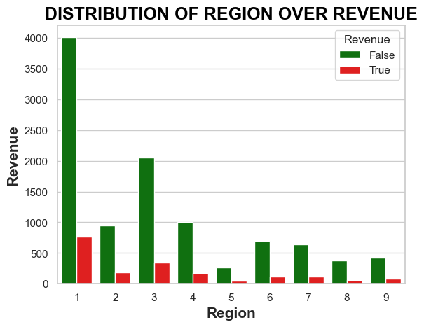

```python
ax4 = sns.countplot(x = 'Region', hue='Revenue', data=df2, palette={'red','green'})
plt.xlabel('Region', fontweight='bold', size=15)
plt.ylabel('Revenue', fontweight='bold', size=15)
plt.title('DISTRIBUTION OF REGION OVER REVENUE', fontweight ='bold',size=18, color='black')
plt.show()
```

Step 19: Linear Regression plot between Administrative and Informational

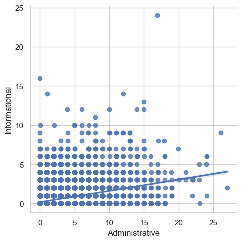

```python
sns.lmplot(x = 'Administrative', y = 'Informational', data = df2, x_jitter = 0.05)
```

Step 20: Multi-variate analysis

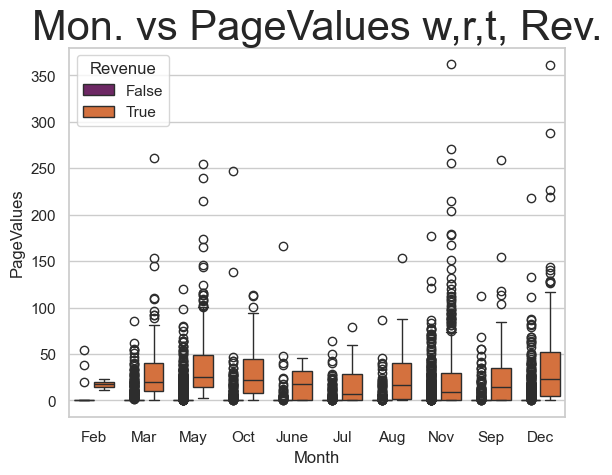

```python
sns.boxplot(x=df2['Month'],y = df2['PageValues'], hue=df2['Revenue'], palette='inferno')
plt.title('Mon. vs PageValues w,r,t, Rev.', fontsize = 30)
```

Step 22: Month vs Bouncerates wrt revenue

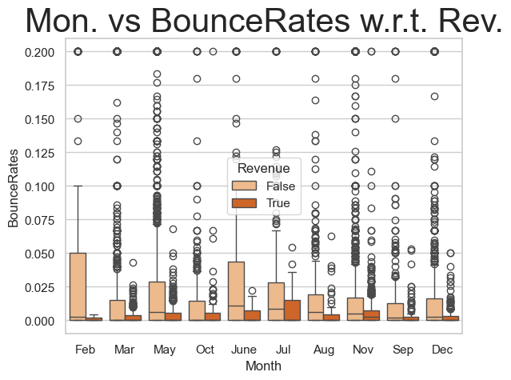

```python
#month vs bouncerates wrt revenue
sns.boxplot(x=df2['Month'], y = df2['BounceRates'], hue = df2['Revenue'], palette = 'Oranges')
plt.title('Mon. vs BounceRates w.r.t. Rev.', fontsize = 30)
```

Step 23: Weekday Vs. Weekday Purchases

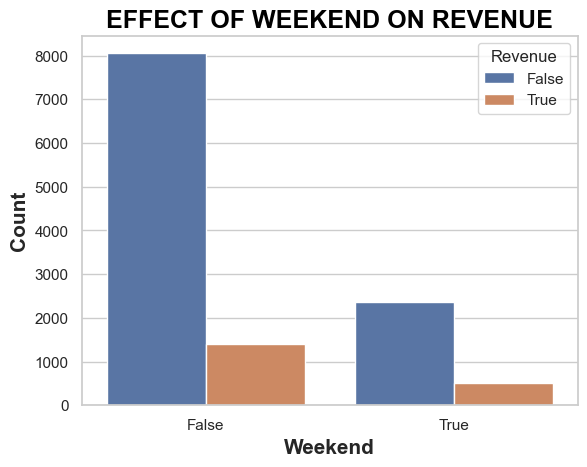

```python
#Analysis of sales on the weekend
Weekend_plot = sns.countplot(x = 'Weekend', hue='Revenue', data = df2)
plt.xlabel('Weekend', fontweight='bold',size=15)
plt.ylabel('Count', fontweight='bold', size=15)
plt.title('EFFECT OF WEEKEND ON REVENUE', fontweight='bold', size=18, color='black')
plt.style.use('ggplot')
plt.show()
```

Step 24: Target Variable Distribution

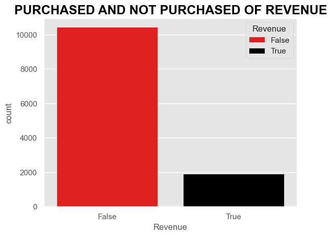

```python
#Target Variable Distribution
sns.countplot(x = 'Revenue', data=df2, hue= "Revenue", palette=('Red', 'black'))
plt.title('PURCHASED AND NOT PURCHASED OF REVENUE', size=18, color='black', fontweight= 'bold')
plt.show()
```

Step 25: REVENUE BY MONTH

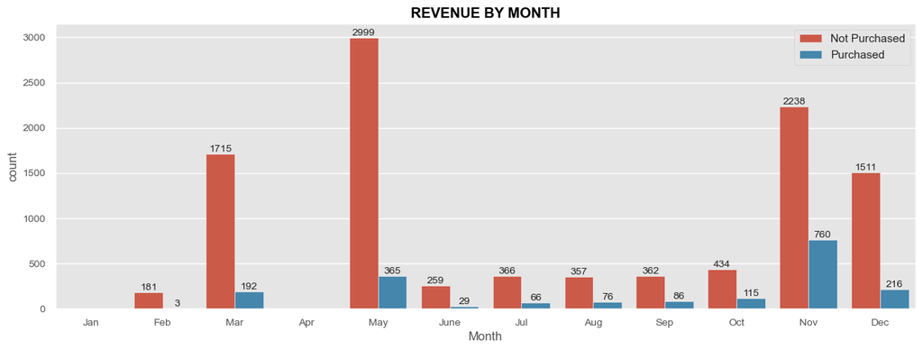

```python
plt.figure(figsize=(15,5))
plt.title("REVENUE BY MONTH", fontsize=14, fontweight='bold',color='black')
orderlist = ['Jan','Feb', 'Mar', 'Apr', 'May', 'June', 'Jul', 'Aug', 'Sep', 'Oct', 'Nov', 'Dec']
ax = sns.countplot(x='Month', data=df2, hue='Revenue', order= orderlist)
ax.legend(labels=['Not Purchased', 'Purchased'])
for i in ax.containers:
    ax.bar_label(i)
    plt.xlabel("Month", fontsize=12)
    plt.ylabel("count", fontsize=12)
    plt.xticks(fontsize=10)
    plt.yticks(fontsize= 10)
   # plt.show()
```

REVENUE BY SPECIAL DAY

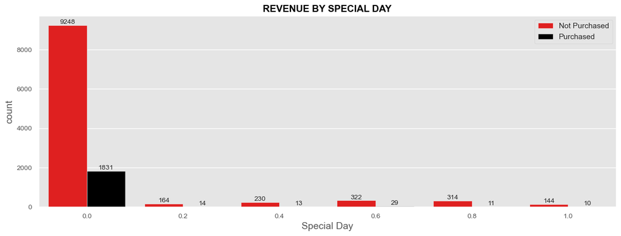

```python
plt.figure(figsize=(15,5))
plt.title("REVENUE BY SPECIAL DAY", fontsize= 14, fontweight='bold', color='black')
ax = sns.countplot(x = 'SpecialDay', data=df2, hue='Revenue', palette =('red', 'black'))
ax.legend(labels=['Not Purchased', 'Purchased'])
for i in ax.containers:
    ax.bar_label(i)
    plt.xlabel("Special Day", fontsize=14)
    plt.ylabel("count", fontsize=14)
    plt.xticks(fontsize=10)
    plt.yticks(fontsize=10)
```

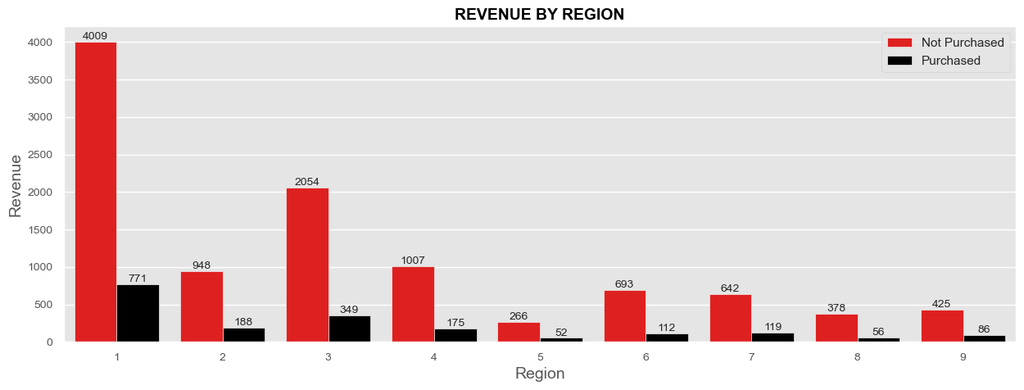

```python
plt.figure(figsize=(15,5))
plt.title("REVENUE BY REGION", fontsize= 14, fontweight='bold', color='black')
ax = sns.countplot(x = 'Region', data=df2, hue='Revenue', palette =('red', 'black'))
ax.legend(labels=['Not Purchased', 'Purchased'])
for i in ax.containers:
    ax.bar_label(i)
    plt.xlabel("Region", fontsize=14)
    plt.ylabel("Revenue", fontsize=14)
    plt.xticks(fontsize=10)
    plt.yticks(fontsize=10)
```

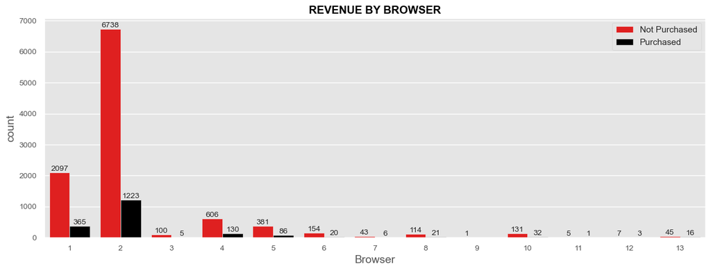

```python
plt.figure(figsize=(15,5))
plt.title("REVENUE BY BROWSER", fontsize= 14, fontweight='bold', color='black')
ax = sns.countplot(x = 'Browser', data=df2, hue='Revenue', palette =('red', 'black'))
ax.legend(labels=['Not Purchased', 'Purchased'])
for i in ax.containers:
    ax.bar_label(i)
    plt.xlabel("Browser", fontsize=14)
    plt.ylabel("count", fontsize=14)
    plt.xticks(fontsize=10)
    plt.yticks(fontsize=10)
```

```python
df2.Revenue.value_counts()
```

```
Revenue
False    10422
True      1908
Name: count, dtype: int64
```

```python
revenue_ratio = df2.Revenue.value_counts(normalize=True)
revenue_ratio
```

```
Revenue
False    0.845255
True     0.154745
Name: proportion, dtype: float64
```

```python
print(df2.Revenue.value_counts())
print(df2.Weekend.value_counts())
```

```
Revenue
False    10422
True      1908
Name: count, dtype: int64
Weekend
False    9462
True     2868
Name: count, dtype: int64
```

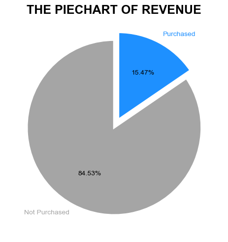

```python
fig, ax =plt.subplots(figsize=(7,5))
x= revenue_ratio
cmap = plt.get_cmap('Greys')
colors = list(cmap(np.linspace(0.45, len(x))))

colors[1] = 'dodgerblue'
labels = ['Not Purchased', 'Purchased']
patches, texts, pcts = ax.pie(
    x, labels=labels, autopct= '%.2f%%',
    wedgeprops={'linewidth': 3.0, 'edgecolor': 'white'},
    textprops={'size': 'medium'},
    startangle=90,
    colors=colors,
    explode= (0, 0.1))

for i, patch in enumerate(patches):
    texts[i].set_color(patch.get_facecolor())
    plt.setp(pcts, color='black')
    plt.setp(texts, fontweight=300)
    ax.set_title('THE PIECHART OF REVENUE', fontsize= 18, color='black', fontweight= 'bold')
    plt.tight_layout()
```

Step 27: Preprocessing

```python
df2.fillna(0, inplace = True)
#Checking the no. of null values in data after imputing the missing value
df2.isnull().sum().sum()
```

```
0
```

Step 28: Plotting Correlation

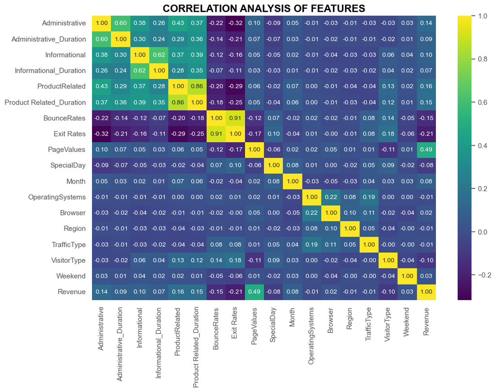

```
Revenue                     1.000000
PageValues                  0.492569
ProductRelated              0.158538
Product Related_Duration    0.152373
Administrative              0.138917
Informational               0.095200
Administrative_Duration     0.093587
Month                       0.080150
Informational_Duration      0.070345
Weekend                     0.029295
Browser                     0.023984
TrafficType                -0.005113
Region                     -0.011595
OperatingSystems           -0.014668
SpecialDay                 -0.082305
VisitorType                -0.104726
BounceRates                -0.150673
Exit Rates                 -0.207071
Name: Revenue, dtype: float64
```

```python
from sklearn.preprocessing import LabelEncoder
#Month
le = LabelEncoder()
df2['Month']=le.fit_transform(df2['Month'])
#VisitorType
df2['VisitorType']= le.fit_transform(df2['VisitorType'])

#Calculate Correlation Matrix
correlation_matrix = df2.corr()

#Create a heatmap
plt.figure(figsize=(12, 8 ))
sns.heatmap(correlation_matrix, annot=True, fmt=".2f", cmap='viridis')
plt.title('CORRELATION ANALYSIS OF FEATURES', size=16, fontweight='bold', color='black')
plt.show()

revenue_correlation=correlation_matrix['Revenue'].sort_values(ascending=False)
print(revenue_correlation)
```

```python
correlation_matrix
```

|  | Administrative | Administrative_Duration | Informational | Informational_Duration | ProductRelated | Product Related_Duration | BounceRates | Exit Rates | PageValues | SpecialDay | Month | OperatingSystems | Browser | Region | TrafficType | VisitorType | Weekend | Revenue |
| --- | --- | --- | --- | --- | --- | --- | --- | --- | --- | --- | --- | --- | --- | --- | --- | --- | --- | --- |
| Administrative | 1.000000 | 0.601583 | 0.376850 | 0.255848 | 0.431119 | 0.373939 | -0.223563 | -0.316483 | 0.098990 | -0.094778 | 0.048560 | -0.006347 | -0.025035 | -0.005487 | -0.033561 | -0.025820 | 0.026417 | 0.138917 |
| Administrative_Duration | 0.601583 | 1.000000 | 0.302710 | 0.238031 | 0.289087 | 0.355422 | -0.144170 | -0.205798 | 0.067608 | -0.073304 | 0.029061 | -0.007343 | -0.015392 | -0.005561 | -0.014376 | -0.023940 | 0.014990 | 0.093587 |
| Informational | 0.376850 | 0.302710 | 1.000000 | 0.618955 | 0.374164 | 0.387505 | -0.116114 | -0.163666 | 0.048632 | -0.048219 | 0.019743 | -0.009527 | -0.038235 | -0.029169 | -0.034491 | 0.055828 | 0.035785 | 0.095200 |
| Informational_Duration | 0.255848 | 0.238031 | 0.618955 | 1.000000 | 0.280046 | 0.347364 | -0.074067 | -0.105276 | 0.030861 | -0.030577 | 0.005987 | -0.009579 | -0.019285 | -0.027144 | -0.024675 | 0.044677 | 0.024078 | 0.070345 |
| ProductRelated | 0.431119 | 0.289087 | 0.374164 | 0.280046 | 1.000000 | 0.860927 | -0.204578 | -0.292526 | 0.056282 | -0.023958 | 0.070299 | 0.004290 | -0.013146 | -0.038122 | -0.043064 | 0.126656 | 0.016092 | 0.158538 |
| Product Related_Duration | 0.373939 | 0.355422 | 0.387505 | 0.347364 | 0.860927 | 1.000000 | -0.184541 | -0.251984 | 0.052823 | -0.036380 | 0.061186 | 0.002976 | -0.007380 | -0.033091 | -0.036377 | 0.119329 | 0.007311 | 0.152373 |
| BounceRates | -0.223563 | -0.144170 | -0.116114 | -0.074067 | -0.204578 | -0.184541 | 1.000000 | 0.913004 | -0.119386 | 0.072702 | -0.023763 | 0.023823 | -0.015772 | -0.006485 | 0.078286 | 0.135536 | -0.046514 | -0.150673 |
| Exit Rates | -0.316483 | -0.205798 | -0.163666 | -0.105276 | -0.292526 | -0.251984 | 0.913004 | 1.000000 | -0.174498 | 0.102242 | -0.039049 | 0.014567 | -0.004442 | -0.008907 | 0.078616 | 0.179144 | -0.062587 | -0.207071 |
| PageValues | 0.098990 | 0.067608 | 0.048632 | 0.030861 | 0.056282 | 0.052823 | -0.119386 | -0.174498 | 1.000000 | -0.063541 | 0.021780 | 0.018508 | 0.045592 | 0.011315 | 0.012532 | -0.111228 | 0.012002 | 0.492569 |
| SpecialDay | -0.094778 | -0.073304 | -0.048219 | -0.030577 | -0.023958 | -0.036380 | 0.072702 | 0.102242 | -0.063541 | 1.000000 | 0.079341 | 0.012652 | 0.003499 | -0.016098 | 0.052301 | 0.085557 | -0.016767 | -0.082305 |
| Month | 0.048560 | 0.029061 | 0.019743 | 0.005987 | 0.070299 | 0.061186 | -0.023763 | -0.039049 | 0.021780 | 0.079341 | 1.000000 | -0.029580 | -0.045913 | -0.032530 | 0.041839 | 0.026481 | 0.029132 | 0.080150 |
| OperatingSystems | -0.006347 | -0.007343 | -0.009527 | -0.009579 | 0.004290 | 0.002976 | 0.023823 | 0.014567 | 0.018508 | 0.012652 | -0.029580 | 1.000000 | 0.223013 | 0.076775 | 0.189154 | 0.001504 | 0.000284 | -0.014668 |
| Browser | -0.025035 | -0.015392 | -0.038235 | -0.019285 | -0.013146 | -0.007380 | -0.015772 | -0.004442 | 0.045592 | 0.003499 | -0.045913 | 0.223013 | 1.000000 | 0.097393 | 0.111938 | -0.021867 | -0.040261 | 0.023984 |
| Region | -0.005487 | -0.005561 | -0.029169 | -0.027144 | -0.038122 | -0.033091 | -0.006485 | -0.008907 | 0.011315 | -0.016098 | -0.032530 | 0.076775 | 0.097393 | 1.000000 | 0.047520 | -0.036191 | -0.000691 | -0.011595 |
| TrafficType | -0.033561 | -0.014376 | -0.034491 | -0.024675 | -0.043064 | -0.036377 | 0.078286 | 0.078616 | 0.012532 | 0.052301 | 0.041839 | 0.189154 | 0.111938 | 0.047520 | 1.000000 | -0.002839 | -0.002221 | -0.005113 |
| VisitorType | -0.025820 | -0.023940 | 0.055828 | 0.044677 | 0.126656 | 0.119329 | 0.135536 | 0.179144 | -0.111228 | 0.085557 | 0.026481 | 0.001504 | -0.021867 | -0.036191 | -0.002839 | 1.000000 | -0.043679 | -0.104726 |
| Weekend | 0.026417 | 0.014990 | 0.035785 | 0.024078 | 0.016092 | 0.007311 | -0.046514 | -0.062587 | 0.012002 | -0.016767 | 0.029132 | 0.000284 | -0.040261 | -0.000691 | -0.002221 | -0.043679 | 1.000000 | 0.029295 |
| Revenue | 0.138917 | 0.093587 | 0.095200 | 0.070345 | 0.158538 | 0.152373 | -0.150673 | -0.207071 | 0.492569 | -0.082305 | 0.080150 | -0.014668 | 0.023984 | -0.011595 | -0.005113 | -0.104726 | 0.029295 | 1.000000 |

Step 29:Categorical

```python
categorical = ['Month', 'VisitorType']
encoded_features = pd.get_dummies(df2[categorical])
encoded_features.head(3)
```

|  | Month | VisitorType |
| --- | --- | --- |
| 0 | 2 | 2 |
| 1 | 2 | 2 |
| 2 | 2 | 2 |

DATA PREPROCESSING

```python
#one hot encoding
data1 = pd.get_dummies(df2)
data1.columns

from sklearn.preprocessing import LabelEncoder
le = LabelEncoder()
df2['Revenue'] = le.fit_transform(df2['Revenue'])
df2['Revenue'].value_counts()
#getting dependent and independent variables
x = data1

#removing the target column revenue from
x = x.drop(['Revenue'], axis = 1)
y = data1['Revenue']
#checking the shapes
print("Shape of x:", x.shape)
print("Shape of y:", y.shape)
```

```
Shape of x: (12330, 17)
Shape of y: (12330,)
```

STEP 31: Splitting the data between train and test sets

```python
#Splitting the data
from sklearn.model_selection import train_test_split
x_train, x_test, y_train, y_test = train_test_split(x, y, test_size = 0.3, random_state = 0)

#Checking the shape

print("Shape of x_train :", x_train.shape)
print("Shape of y_train :", y_train.shape)
print("Shape of x_test:", x_test.shape)
print("Shape of y_test:", y_test.shape)
```

```
Shape of x_train : (8631, 17)
Shape of y_train : (8631,)
Shape of x_test: (3699, 17)
Shape of y_test: (3699,)
```

A. RANDOMFOREST CLASSIFIER

STEP 32: RandomForest Classifier model Building

```python
#Modelling
from sklearn.ensemble import RandomForestClassifier

from sklearn.metrics import confusion_matrix

from sklearn.metrics import classification_report
rf_model = RandomForestClassifier()
rf_model.fit(x_train, y_train)
rf_pred = rf_model.predict(x_test)

#Training and testing Accuracy
print ("RandomForest:")
print("Training Accuracy :", rf_model.score(x_train, y_train))

print("Testing Accuracy :", rf_model.score(x_test, y_test))
```

```
RandomForest:
Training Accuracy : 1.0
Testing Accuracy : 0.895647472289808
```

Step 33: Confusion Matrix for Random Forest

```
CONFUSION MATRIX FOR RANDOM FOREST:
[[2958  119]
 [ 267  355]]
CLASSIFICATION MATRIX FOR RANDOM FOREST:
              precision    recall  f1-score   support

       False       0.92      0.96      0.94      3077
        True       0.75      0.57      0.65       622

    accuracy                           0.90      3699
   macro avg       0.83      0.77      0.79      3699
weighted avg       0.89      0.90      0.89      3699
```

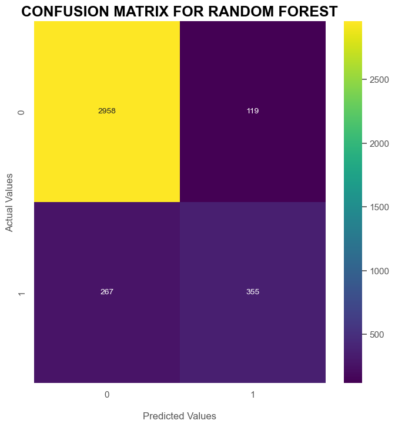

```python
#Confusion Matrix
print('CONFUSION MATRIX FOR RANDOM FOREST:')
print(confusion_matrix(y_test, rf_model.predict(x_test)))
#Classification Matrix
print('CLASSIFICATION MATRIX FOR RANDOM FOREST:')
print(classification_report(y_test, rf_model.predict(x_test)))

#plot confusion matrix
cm = confusion_matrix(y_test, rf_model.predict(x_test))
fig, ax = plt.subplots(figsize=(8, 8))
sns.heatmap(cm, annot=True, fmt='d', cmap='viridis')
plt.title("CONFUSION MATRIX FOR RANDOM FOREST", fontweight='bold',size=18, color = 'black')
ax.set_xlabel('\nPredicted Values')
ax.set_ylabel('Actual Values');
ax.xaxis.set_xticklabels=(['Not Puchase', 'Purchased'])
ax.yaxis.set_yticklabels= (['Not purchase', 'Purchased'])
```

STEP 34: Plotting The ROC curve for Random Forest

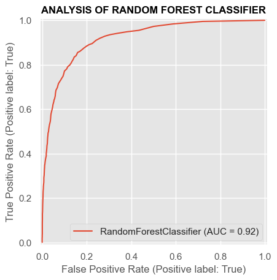

```python
from sklearn.metrics import RocCurveDisplay
import matplotlib.pyplot as plt
rf_disp = RocCurveDisplay.from_estimator(rf_model, x_test, y_test)
plt.title('ANALYSIS OF RANDOM FOREST CLASSIFIER', size=12, fontweight='bold', color='black')
plt.show()
```

STEP 35: Showing the Importance Features of RandomForest Classifier

```python
rf_model.fit(x_train, y_train)

#Get feature importances
importances = rf_model.feature_importances_
feature_importance = pd.DataFrame({'Feature' : x_test.columns, 'Importance': importances})

#print the sorted feature importance
print("Feature Importance Scores:")
print(feature_importance)
```

```
Feature Importance Scores:
                     Feature  Importance
0             Administrative    0.043427
1    Administrative_Duration    0.055900
2              Informational    0.016893
3     Informational_Duration    0.027183
4             ProductRelated    0.070826
5   Product Related_Duration    0.092235
6                BounceRates    0.057672
7                 Exit Rates    0.089760
8                 PageValues    0.381496
9                 SpecialDay    0.003467
10                     Month    0.039838
11          OperatingSystems    0.017812
12                   Browser    0.018754
13                    Region    0.030348
14               TrafficType    0.031245
15               VisitorType    0.013417
16                   Weekend    0.009727
```

```python
from sklearn.feature_selection import RFE
from sklearn.model_selection import train_test_split
rf_model = RandomForestClassifier()
#Apply RFE
#selector = RFE(rf_model, n_features_to_select=3)
rf_model.fit(x_train, y_train)
#Selected Features
importances = rf_model.feature_importances_
feature_importance = pd.DataFrame({'Feature': x_test.columns, 'Importance': importances})
selected_features = feature_importance[feature_importance['Importance'] > 0.05]
print("Selected Features:", selected_features)
```

```
Selected Features:                     Feature  Importance
1   Administrative_Duration    0.060536
4            ProductRelated    0.071040
5  Product Related_Duration    0.085853
6               BounceRates    0.057980
7                Exit Rates    0.089478
8                PageValues    0.388117
```

B. LOGISTIC REGRESSION

Step 37: Building Logistic Regression Model

```python
#Modelling
from sklearn.linear_model import LogisticRegression

from sklearn.metrics import confusion_matrix

from sklearn.metrics import classification_report
lr_model = LogisticRegression(max_iter=1000, solver='liblinear')
lr_model.fit(x_train, y_train)
lr_pred = lr_model.predict(x_test)

#Training and testing Accuracy
print ("Logistic Regression:")
print("Training Accuracy :", lr_model.score(x_train, y_train))

print("Testing Accuracy :", lr_model.score(x_test, y_test))
```

```
Logistic Regression:
Training Accuracy : 0.8883095817402387
Testing Accuracy : 0.8718572587185726
```

Step 38: CONFUSION MATRIX FOR LOGISTIC REGRESSION

```
CONFUSION MATRIX FOR LOGISTIC REGRESSION:
[[3003   74]
 [ 400  222]]
CLASSIFICATION MATRIX FOR LOGISTIC REGRESSION:
              precision    recall  f1-score   support

       False       0.88      0.98      0.93      3077
        True       0.75      0.36      0.48       622

    accuracy                           0.87      3699
   macro avg       0.82      0.67      0.71      3699
weighted avg       0.86      0.87      0.85      3699
```

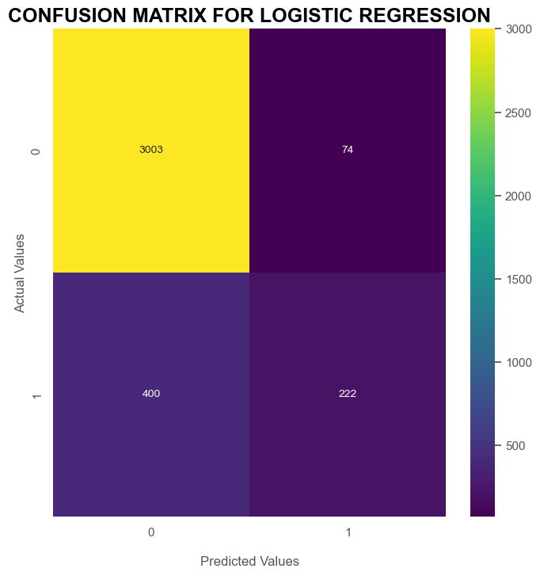

```python
#Confusion Matrix
print('CONFUSION MATRIX FOR LOGISTIC REGRESSION:')
print(confusion_matrix(y_test, lr_model.predict(x_test)))
#Classification Matrix
print('CLASSIFICATION MATRIX FOR LOGISTIC REGRESSION:')
print(classification_report(y_test, lr_model.predict(x_test)))

#plot confusion matrix
cm = confusion_matrix(y_test, lr_model.predict(x_test))
fig, ax = plt.subplots(figsize=(8, 8))
sns.heatmap(cm, annot=True, fmt='d', cmap='viridis')
plt.title("CONFUSION MATRIX FOR LOGISTIC REGRESSION", size= 18, color='black', fontweight='bold')
ax.set_xlabel('\nPredicted Values')
ax.set_ylabel('Actual Values');
ax.xaxis.set_xticklabels=(['Not Puchase', 'Purchased'])
ax.yaxis.set_yticklabels= (['Not purchase', 'Purchased'])
```

Step 39: Plotting ROC curve for Logistic Regression

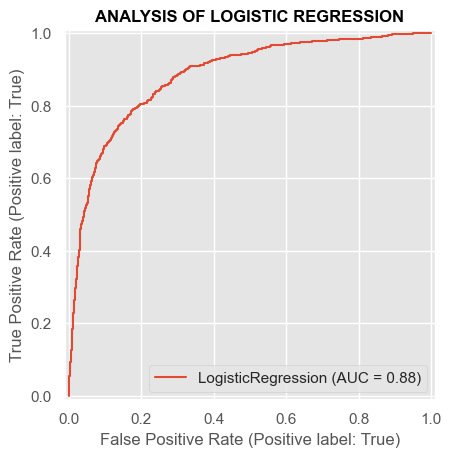

```python
from sklearn.metrics import RocCurveDisplay
import matplotlib.pyplot as plt
lr_disp = RocCurveDisplay.from_estimator(lr_model, x_test, y_test)
plt.title("ANALYSIS OF LOGISTIC REGRESSION", size=12, fontweight='bold', color='black')
plt.show()
```

STEP 40:THE P_VALUES FOR LOGISTIC REGRESSION

```python
from sklearn.preprocessing import LabelEncoder, OrdinalEncoder
from sklearn.model_selection import GridSearchCV
from sklearn.metrics import mean_squared_error, mean_absolute_error
from statsmodels.tsa.arima.model import ARIMA
from sklearn.model_selection import train_test_split
from sklearn.linear_model import LogisticRegression


#feature selection
#X = df2[['Administrative_Duration', 'Region', 'TrafficType', 'OperatingSystems','VisitorType','Browser','Informational_Duration','Product Related_Duration', 'BounceRates', 'Exit Rates', 'PageValues']]
X = df2[['Administrative','Administrative_Duration', 'Informational', 'Informational_Duration','ProductRelated','Product Related_Duration',
        'BounceRates', 'Exit Rates', 'PageValues', 'SpecialDay', 'Month','OperatingSystems','Browser','Region', 'TrafficType', 'VisitorType']]
y = df2['Revenue']



import statsmodels.api as sm

X = sm.add_constant(X)
lr_model = sm.Logit(y, X).fit()
```

```
Optimization terminated successfully.
         Current function value: 0.297153
         Iterations 9
```

```python
print(lr_model.summary())
```

```
                           Logit Regression Results
==============================================================================
Dep. Variable:                Revenue   No. Observations:                12330
Model:                          Logit   Df Residuals:                    12313
Method:                           MLE   Df Model:                           16
Date:                Tue, 19 Nov 2024   Pseudo R-squ.:                  0.3103
Time:                        22:36:21   Log-Likelihood:                -3663.9
converged:                       True   LL-Null:                       -5312.4
Covariance Type:            nonrobust   LLR p-value:                     0.000
============================================================================================
                               coef    std err          z      P>|z|      [0.025      0.975]
--------------------------------------------------------------------------------------------
const                       -2.2316      0.149    -15.006      0.000      -2.523      -1.940
Administrative               0.0021      0.011      0.188      0.851      -0.019       0.024
Administrative_Duration     -0.0002      0.000     -0.778      0.437      -0.001       0.000
Informational                0.0297      0.027      1.111      0.267      -0.023       0.082
Informational_Duration    7.206e-05      0.000      0.324      0.746      -0.000       0.001
ProductRelated               0.0035      0.001      3.076      0.002       0.001       0.006
Product Related_Duration  5.688e-05   2.73e-05      2.083      0.037    3.37e-06       0.000
BounceRates                 -2.8734      3.132     -0.917      0.359      -9.012       3.265
Exit Rates                 -15.2430      2.362     -6.452      0.000     -19.873     -10.613
PageValues                   0.0801      0.002     34.043      0.000       0.075       0.085
SpecialDay                  -0.9753      0.218     -4.479      0.000      -1.402      -0.549
Month                        0.1063      0.014      7.793      0.000       0.080       0.133
OperatingSystems            -0.0876      0.038     -2.304      0.021      -0.162      -0.013
Browser                      0.0343      0.018      1.868      0.062      -0.002       0.070
Region                      -0.0153      0.013     -1.177      0.239      -0.041       0.010
TrafficType                  0.0075      0.008      0.915      0.360      -0.009       0.024
VisitorType                 -0.1810      0.042     -4.274      0.000      -0.264      -0.098
============================================================================================
```

Step 41: BIC for Logistic Regression

```python
#BIC
bic_value = lr_model.bic
print(f"BIC: {bic_value}")
```

```
BIC: 7487.922097673219
```

Step 42:AIC for Logistic Regression

```python
#AIC
aic_value = lr_model.aic
print(f"BIC: {aic_value}")
```

```
BIC: 7361.785657538526
```

```python
p_values = lr_model.pvalues
significant_features = p_values[p_values < 0.05]
print("P_VALUES:\n", p_values)
print("Significant Predictors:\n", significant_features)
```

```
P_VALUES:
 const                        6.732317e-51
Administrative               8.506312e-01
Administrative_Duration      4.366703e-01
Informational                2.665800e-01
Informational_Duration       7.459325e-01
ProductRelated               2.099078e-03
Product Related_Duration     3.721492e-02
BounceRates                  3.589038e-01
Exit Rates                   1.100523e-10
PageValues                  5.090279e-254
SpecialDay                   7.482472e-06
Month                        6.549530e-15
OperatingSystems             2.123575e-02
Browser                      6.176505e-02
Region                       2.391753e-01
TrafficType                  3.601454e-01
VisitorType                  1.921443e-05
dtype: float64
Significant Predictors:
 const                        6.732317e-51
ProductRelated               2.099078e-03
Product Related_Duration     3.721492e-02
Exit Rates                   1.100523e-10
PageValues                  5.090279e-254
SpecialDay                   7.482472e-06
Month                        6.549530e-15
OperatingSystems             2.123575e-02
VisitorType                  1.921443e-05
dtype: float64
```

Step 43: Coefficient for Logistic regression

```python
coefficients = lr_model.params
print("Coefficients:\n", coefficients)
```

```
Coefficients:
 const                       -2.231558
Administrative               0.002063
Administrative_Duration     -0.000152
Informational                0.029668
Informational_Duration       0.000072
ProductRelated               0.003505
Product Related_Duration     0.000057
BounceRates                 -2.873353
Exit Rates                 -15.242994
PageValues                   0.080075
SpecialDay                  -0.975327
Month                        0.106267
OperatingSystems            -0.087574
Browser                      0.034334
Region                      -0.015290
TrafficType                  0.007483
VisitorType                 -0.181022
dtype: float64
```

C. DECISION TREE

Step 44: Building Decision Tree model

```python
#Modelling
from sklearn.tree import DecisionTreeClassifier

from sklearn.metrics import confusion_matrix

from sklearn.metrics import classification_report
dt_model = DecisionTreeClassifier()
dt_pred= dt_model.fit(x_train, y_train)
dt_pred = dt_model.predict(x_test)

#Training and testing Accuracy
print ("Logistic Regression:")
print("Training Accuracy :", dt_model.score(x_train, y_train))

print("Testing Accuracy :", dt_model.score(x_test, y_test))
```

```
Logistic Regression:
Training Accuracy : 1.0
Testing Accuracy : 0.8626655852933225
```

Step 45: Printing Confusion Matrix for Decision Tree

```
CONFUSION MATRIX FOR DECISION TREE:
[[2842  235]
 [ 273  349]]
CLASSIFICATION MATRIX FOR DECISION TREE:
              precision    recall  f1-score   support

       False       0.91      0.92      0.92      3077
        True       0.60      0.56      0.58       622

    accuracy                           0.86      3699
   macro avg       0.75      0.74      0.75      3699
weighted avg       0.86      0.86      0.86      3699
```

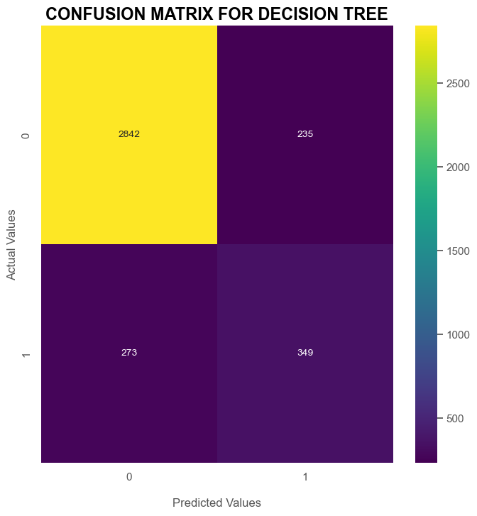

```python
#Confusion Matrix
print('CONFUSION MATRIX FOR DECISION TREE:')
print(confusion_matrix(y_test, dt_model.predict(x_test)))
#Classification Matrix
print('CLASSIFICATION MATRIX FOR DECISION TREE:')
print(classification_report(y_test, dt_model.predict(x_test)))

#plot confusion matrix
cm = confusion_matrix(y_test, dt_model.predict(x_test))
fig, ax = plt.subplots(figsize=(8, 8))
sns.heatmap(cm, annot=True, fmt='d', cmap='viridis')
plt.title("CONFUSION MATRIX FOR DECISION TREE", color='black', fontweight='bold', size=17)
ax.set_xlabel('\nPredicted Values')
ax.set_ylabel('Actual Values');
ax.xaxis.set_xticklabels=(['Not Puchase', 'Purchased'])
ax.yaxis.set_yticklabels= (['Not purchase', 'Purchased'])
```

Step 46: Plotting the ROC curve for DecisionTreeClassifier

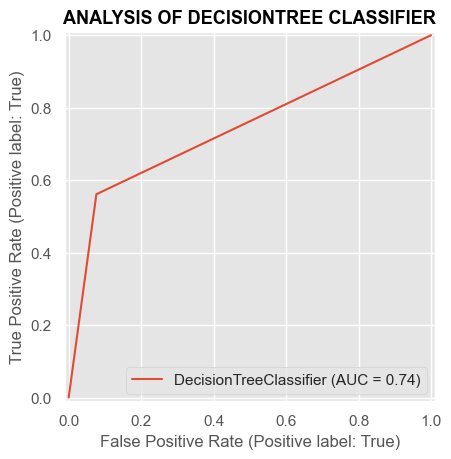

```python
from sklearn.metrics import RocCurveDisplay
import matplotlib.pyplot as plt
dt_disp = RocCurveDisplay.from_estimator(dt_model, x_test, y_test)
plt.title("ANALYSIS OF DECISIONTREE CLASSIFIER", color='black', fontweight= 'bold', size=13)
plt.show()
```

Step 47: Feature Importance for Decision tree Classifier

```python
dt_model.fit(x_train, y_train)

#Get feature importances
importances = dt_model.feature_importances_
feature_importance = pd.DataFrame({'Feature' : x_test.columns, 'Importance': importances})

#Sorted features by Importance
sorted_importance = feature_importance.sort_values(by = 'Importance', ascending=False)
#print the sorted feature importance
print(sorted_importance)
```

```
                     Feature  Importance
8                 PageValues    0.435987
7                 Exit Rates    0.074569
5   Product Related_Duration    0.074531
6                BounceRates    0.073343
4             ProductRelated    0.067832
1    Administrative_Duration    0.051509
0             Administrative    0.043375
10                     Month    0.040068
13                    Region    0.029052
14               TrafficType    0.026419
3     Informational_Duration    0.025002
2              Informational    0.015484
12                   Browser    0.013182
11          OperatingSystems    0.012426
16                   Weekend    0.009283
15               VisitorType    0.007423
9                 SpecialDay    0.000516
```

STEP 48: RECRURSIVE FEATURES ELIMATION FOR DECISION TREE CLASSIFIER

```python
from sklearn.feature_selection import RFE
from sklearn.model_selection import train_test_split
rf_model = RandomForestClassifier()
#Apply RFE
#selector = RFE(rf_model, n_features_to_select=3)
dt_model.fit(x_train, y_train)
#Selected Features
importances = dt_model.feature_importances_
feature_importance = pd.DataFrame({'Feature': x_test.columns, 'Importance': importances})
selected_features = feature_importance[feature_importance['Importance'] > 0.05]
print("Selected Features:", selected_features)
```

```
Selected Features:                     Feature  Importance
1   Administrative_Duration    0.060672
4            ProductRelated    0.067969
5  Product Related_Duration    0.075055
6               BounceRates    0.075401
7                Exit Rates    0.070384
8                PageValues    0.431478
```

```python
#RLE FOR DECISION TREE CLASSIFIER
from sklearn.feature_selection import RFE
from sklearn.model_selection import train_test_split
dt_model = DecisionTreeClassifier()
#Apply RFE
selector = RFE(dt_model, n_features_to_select=6)
selector = selector.fit(x_train, y_train)
#Selected Features
selected_features = x_test.columns[selector.support_]
print("Selected Features:", selected_features)
```

```
Selected Features: Index(['Administrative_Duration', 'ProductRelated', 'Product Related_Duration',
       'BounceRates', 'Exit Rates', 'PageValues'],
      dtype='object')
```

D. Support Vector Machine

Step 49: Building Support Vector Model

```python
#Modelling
from sklearn.svm import SVC
from sklearn import svm

from sklearn.metrics import confusion_matrix

from sklearn.metrics import classification_report
svm_model = SVC()
svm_model.fit(x_train, y_train)
svm_pred = svm_model.predict(x_test)

#Training and testing Accuracy
print ("Support Vector Machine:")
print("Training Accuracy :", svm_model.score(x_train, y_train))

print("Testing Accuracy :", svm_model.score(x_test, y_test))
```

```
Support Vector Machine:
Training Accuracy : 0.8525083999536555
Testing Accuracy : 0.8340091916734252
```

Step 50: Plotting the confusion matrix for Support Vector Machine

```
CONFUSION MATRIX FOR SUPPORT VECTOR MACHINE:
[[3077    0]
 [ 614    8]]
CLASSIFICATION MATRIX FOR SUPPORT VECTOR MACHINE:
              precision    recall  f1-score   support

       False       0.83      1.00      0.91      3077
        True       1.00      0.01      0.03       622

    accuracy                           0.83      3699
   macro avg       0.92      0.51      0.47      3699
weighted avg       0.86      0.83      0.76      3699
```

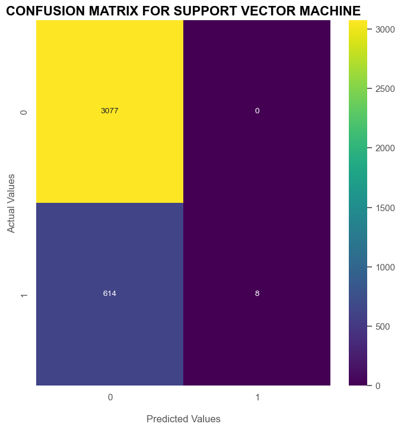

```python
#Confusion Matrix
print('CONFUSION MATRIX FOR SUPPORT VECTOR MACHINE:')
print(confusion_matrix(y_test, svm_model.predict(x_test)))
#Classification Matrix
print('CLASSIFICATION MATRIX FOR SUPPORT VECTOR MACHINE:')
print(classification_report(y_test, svm_model.predict(x_test)))

#plot confusion matrix
cm = confusion_matrix(y_test, svm_model.predict(x_test))
fig, ax = plt.subplots(figsize=(8, 8))
sns.heatmap(cm, annot=True, fmt='d', cmap='viridis')
plt.title('CONFUSION MATRIX FOR SUPPORT VECTOR MACHINE', size=16, color='black', fontweight='bold')
ax.set_xlabel('\nPredicted Values')
ax.set_ylabel('Actual Values');
ax.xaxis.set_xticklabels=(['Not Puchase', 'Purchased'])
ax.yaxis.set_yticklabels= (['Not purchase', 'Purchased'])
```

Step 51: Plotting the ROC curve for Support Vector Machine

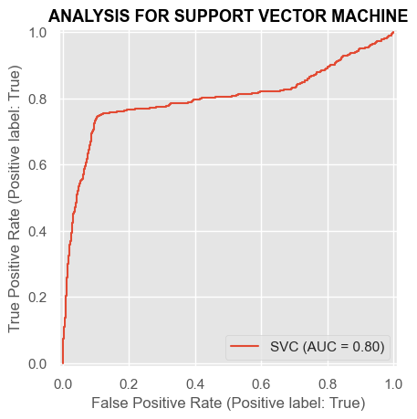

```python
from sklearn.metrics import RocCurveDisplay
import matplotlib.pyplot as plt
svm_disp = RocCurveDisplay.from_estimator(svm_model, x_test, y_test)
plt.title("ANALYSIS FOR SUPPORT VECTOR MACHINE", size= 13, color='black', fontweight='bold')
plt.show()
```

E. Gradient Boosting Classifier

Step 52: Building Gradient Boosting Classifier Model

```python
#Modelling
from sklearn.ensemble import GradientBoostingClassifier


from sklearn.metrics import confusion_matrix

from sklearn.metrics import classification_report
gbc_model = GradientBoostingClassifier()
gbc_model.fit(x_train, y_train)
gbc_pred = gbc_model.predict(x_test)

#Training and testing Accuracy
print ("Gradient Boosting Classifier:")
print("Training Accuracy :", gbc_model.score(x_train, y_train))

print("Testing Accuracy :", gbc_model.score(x_test, y_test))
```

```
Gradient Boosting Classifier:
Training Accuracy : 0.9238790406673618
Testing Accuracy : 0.8926736955934036
```

Step 53: Plotting confusion matrix for Gradient Boosting Classifier

```
CONFUSION MATRIX FOR GRADIENT BOOSTING CLASSIFIER:
[[2946  131]
 [ 266  356]]
CLASSIFICATION MATRIX FOR GRADIENT BOOSTING CLASSIFIER:
              precision    recall  f1-score   support

       False       0.92      0.96      0.94      3077
        True       0.73      0.57      0.64       622

    accuracy                           0.89      3699
   macro avg       0.82      0.76      0.79      3699
weighted avg       0.89      0.89      0.89      3699
```

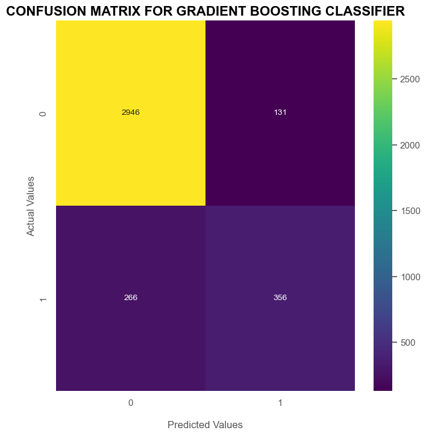

```python
#Confusion Matrix
print('CONFUSION MATRIX FOR GRADIENT BOOSTING CLASSIFIER:')
print(confusion_matrix(y_test, gbc_model.predict(x_test)))
#Classification Matrix
print('CLASSIFICATION MATRIX FOR GRADIENT BOOSTING CLASSIFIER:')
print(classification_report(y_test, gbc_model.predict(x_test)))

#plot confusion matrix
cm = confusion_matrix(y_test, gbc_model.predict(x_test))
fig, ax = plt.subplots(figsize=(8, 8))
sns.heatmap(cm, annot=True, fmt='d', cmap='viridis')
plt.title("CONFUSION MATRIX FOR GRADIENT BOOSTING CLASSIFIER", color='black', fontweight='bold', size=16)
ax.set_xlabel('\nPredicted Values')
ax.set_ylabel('Actual Values');
ax.xaxis.set_xticklabels=(['Not Puchase', 'Purchased'])
ax.yaxis.set_yticklabels= (['Not purchase', 'Purchased'])
```

Step 54: Plotting the ROC Curve for Gradient Boosting Classifier

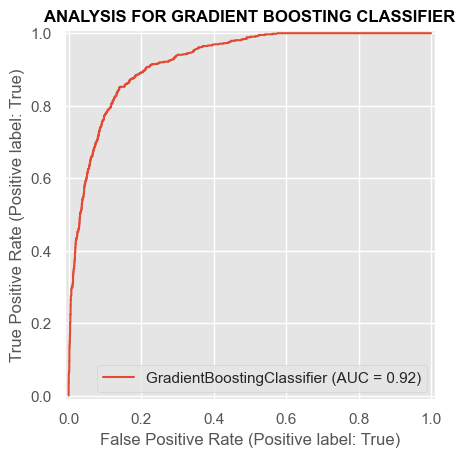

```python
from sklearn.metrics import RocCurveDisplay
import matplotlib.pyplot as plt
gbc_disp = RocCurveDisplay.from_estimator(gbc_model, x_test, y_test)
plt.title("ANALYSIS FOR GRADIENT BOOSTING CLASSIFIER", color='black', size= 12, fontweight= 'bold')
plt.show()
```

STEP 55: Showing the features importance for Gradient Boosting Classifier

```python
gbc_model.fit(x_train, y_train)

#Get feature importances
importances = gbc_model.feature_importances_
feature_importance = pd.DataFrame({'Feature' : x_test.columns, 'Importance': importances})

#Sorted features by Importance
sorted_importance = feature_importance.sort_values(by = 'Importance', ascending=False)
#print the sorted feature importance
print("Feature Importance Scores:")
print(sorted_importance)
```

```
Feature Importance Scores:
                     Feature  Importance
8                 PageValues    0.746286
10                     Month    0.046823
6                BounceRates    0.042661
5   Product Related_Duration    0.033484
7                 Exit Rates    0.027527
0             Administrative    0.026714
4             ProductRelated    0.025584
15               VisitorType    0.019826
1    Administrative_Duration    0.008138
3     Informational_Duration    0.007845
14               TrafficType    0.003991
2              Informational    0.003923
13                    Region    0.002428
11          OperatingSystems    0.001998
12                   Browser    0.001539
9                 SpecialDay    0.001154
16                   Weekend    0.000080
```

```python
from sklearn.feature_selection import RFE
from sklearn.model_selection import train_test_split
#Apply RFE
#selector = RFE(rf_model, n_features_to_select=3)
gbc_model.fit(x_train, y_train)
#Selected Features
importances = gbc_model.feature_importances_
feature_importance = pd.DataFrame({'Feature': x_test.columns, 'Importance': importances})
selected_features = feature_importance[feature_importance['Importance'] > 0.04]
print("Selected Features:", selected_features)
```

```
Selected Features:         Feature  Importance
6   BounceRates    0.042652
8    PageValues    0.746444
10        Month    0.046865
```

Step 57: Building Naive Bayes Model